# final project__

2022-06-05

# Introduction

##### The purpose of this project is to generate several machine learning models that will predict which passengers would survive the Titanic shipwreck, and choose the best model. We are going to run Decision model, Random Forest model, Boosted Tree model, and Nearest Neighbor model.

##### This project uses on a data of the Kaggle ‘Titanic - Machine Learning from Disaster’(‘https://www.kaggle.com/competitions/titanic/data’), the data of Titanic’s passengers,name, age, gender, socio-economic class, etc.

##### These are variables of this project’s data.

##### 1. passenger_id: id of passenger

##### 2. survived: ‘’Yes’ means the passenger survived, ‘No’ means the passenger didn’t survive.

##### 3. pclass: ticket class, ‘1’ means 1st class, ‘2’ means 2nd class, ‘3’ means 3rd class.

##### 4. name: name of passenger, passenger title, surname of passenger

##### 5. sex: sex of the passenger

##### 6. age: age of the passenger

##### 7. sib_sp: number of siblings or spouses aboard the Titanic

##### 8. parch: number of parents or children aboard the Titanic

##### 9. ticket: ticket number

##### 10. fair: passenger fare

##### 11. cabin: cabin number

##### 12. embarked: ‘C’means ’Cherbourg’, ‘Q’ means ‘Queenstown’, ‘S’ means ‘Southampton’

# Loading Data and Packages

```r
# Load data
titanic <- read.csv("C:/Users/82107/Desktop/PSTAT 131,231/FINAL PROJECT/titanic.csv")
```

```r
# Load packages
library(klaR)
library(tidyverse)
library(tidymodels)
```

```r
library(corrplot)
library(corrr)
library(discrim)
library(ISLR)
library(vip)
library(janitor)
library(glmnet)
library(ggplot2)
library(ggthemes)
library(dplyr)
library(rpart.plot)
library(kknn)
tidymodels_prefer()

# set seed
set.seed(1234)
```

# Data Cleaning

To run several machine learning models, ‘survived’ and ‘pclass’ should be changed to factors. Let’s reorder ‘survived’ to make “Yes’ first level.

```r
titanic <- titanic %>%
  mutate(survived = factor(survived, levels = c("Yes", "No")),
         pclass = factor(pclass))
```

Let’s clean names.

```r
titanic <- titanic %>%
  clean_names()
```

# Data Splitting & Cross-Validation

Before EDA, Let’s split the data into a training set, and a testing set by 0.7 proportion. We are going to stratify on the outcome variable, “survived” for this project.

```r
set.seed(1234)
data_split <- initial_split(titanic, strata = survived, prop = 0.7)

data_train <- training(data_split)
data_test <- testing(data_split)

dim(data_train)
```

```
## [1] 623  12
```

```r
dim(data_test)
```

```
## [1] 268  12
```

The training data set has about 620 observations and the testing data has about 270 observations.

##### Let’s fold the training set using *v*-fold cross-validation, with `v = 10`, and stratify on the outcome variable “survived”.

```r
titanic_folds <- vfold_cv(data_train, v = 10, strata = survived)
```

# Exploratory Data Analysis(EDA)

##### This entire exploratory data analysis will be based only on the training set, which has 623 observations.

## Explores outcome variable distribution

##### Let’s explore outcome variable ‘survived’ distribution.

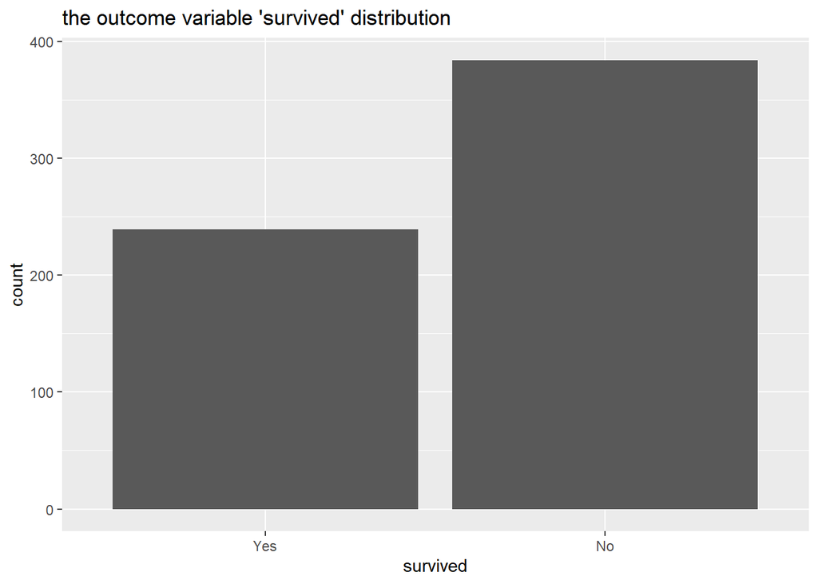

```r
data_train %>%
  ggplot(aes(x = survived)) +
  geom_bar() +
  labs(
    title = "the outcome variable 'survived' distribution"
  )
```

##### There is a level imbalance in the outcome variable, because there are more observations for one level ‘No’, than the other, ‘Yes’. Therefore, it is worthwhile and required to stratify in the cross-validation.

## Assess missing data patterns

```r
summary(titanic)
```

```
##   passenger_id   survived  pclass      name               sex
##  Min.   :  1.0   Yes:342   1:216   Length:891         Length:891
##  1st Qu.:223.5   No :549   2:184   Class :character   Class :character
##  Median :446.0             3:491   Mode  :character   Mode  :character
##  Mean   :446.0
##  3rd Qu.:668.5
##  Max.   :891.0
##
##       age            sib_sp          parch           ticket
##  Min.   : 0.42   Min.   :0.000   Min.   :0.0000   Length:891
##  1st Qu.:20.12   1st Qu.:0.000   1st Qu.:0.0000   Class :character
##  Median :28.00   Median :0.000   Median :0.0000   Mode  :character
##  Mean   :29.70   Mean   :0.523   Mean   :0.3816
##  3rd Qu.:38.00   3rd Qu.:1.000   3rd Qu.:0.0000
##  Max.   :80.00   Max.   :8.000   Max.   :6.0000
##  NA's   :177
##       fare           cabin             embarked
##  Min.   :  0.00   Length:891         Length:891
##  1st Qu.:  7.91   Class :character   Class :character
##  Median : 14.45   Mode  :character   Mode  :character
##  Mean   : 32.20
##  3rd Qu.: 31.00
##  Max.   :512.33
##
```

##### We can know that the only variable with missingness is ‘age’, which has missing 177 values. So, we have to manipulate these missing values to explore relationships among other variables, and add an imputation step when we make a recipe later.

## Explore realtionships among variables.

##### 1. Using the training data set, let’s create a correlation matrix of all continuous variables and visualize it.

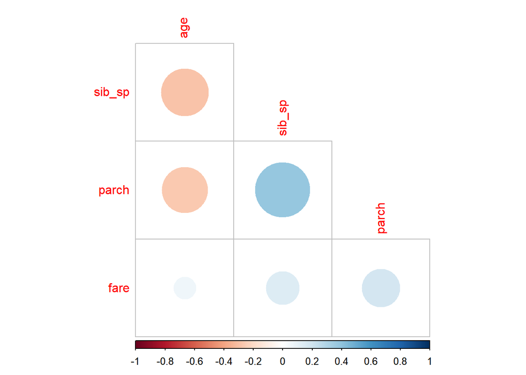

```r
data_train %>%
  select(where(is.numeric), -passenger_id) %>%
  cor(use = "complete.obs") %>%
  corrplot(type = "lower", diag = FALSE)
```

##### ‘age’ and ‘sib_sp’ are negatively correlated, which implies that older passengers are less likely to have sibling on board. ‘age’ and ‘parch’ are also negatively correlated, which implies that older passengers are less likely to have parents or children on board. ‘parch’ and ‘sib_sp’ are positively correltated, which implies that having one on board means having the other on board is also likely.

```r
# Create a family size variable including the passenger themselves
data_train2 <- data_train
data_train2$fsize <- data_train2$sib_sp + data_train2$parch + 1
```

##### Let’s visualize the relationship between new variable ‘family size’ and ‘survived’.

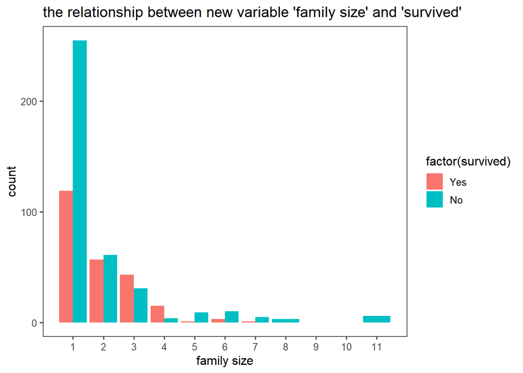

```r
ggplot(data_train2[1:623,], aes(x = fsize, fill = factor(survived))) +
  geom_bar(stat='count', position='dodge') +
  scale_x_continuous(breaks=c(1:11)) +
  labs(x = 'family size') +
  theme_few() +
  labs(
    title = "the relationship between new variable 'family size' and 'survived'"
  )
```

##### By this ggplot, we can see that those with no family and those with family sizes above 4 tended to be less likely to survive. Let’s divide ‘family size’ variable into three levels, then make ‘family type’ variable.

```r
# divide 'family size' variable into three levels, then make 'family type' variable.
data_train2$ftype[data_train2$fsize == 1] <- 'single'
data_train2$ftype[data_train2$fsize > 1 & data_train2$fsize < 5] <- 'small'
data_train2$ftype[data_train2$fsize > 4] <- 'large'
```

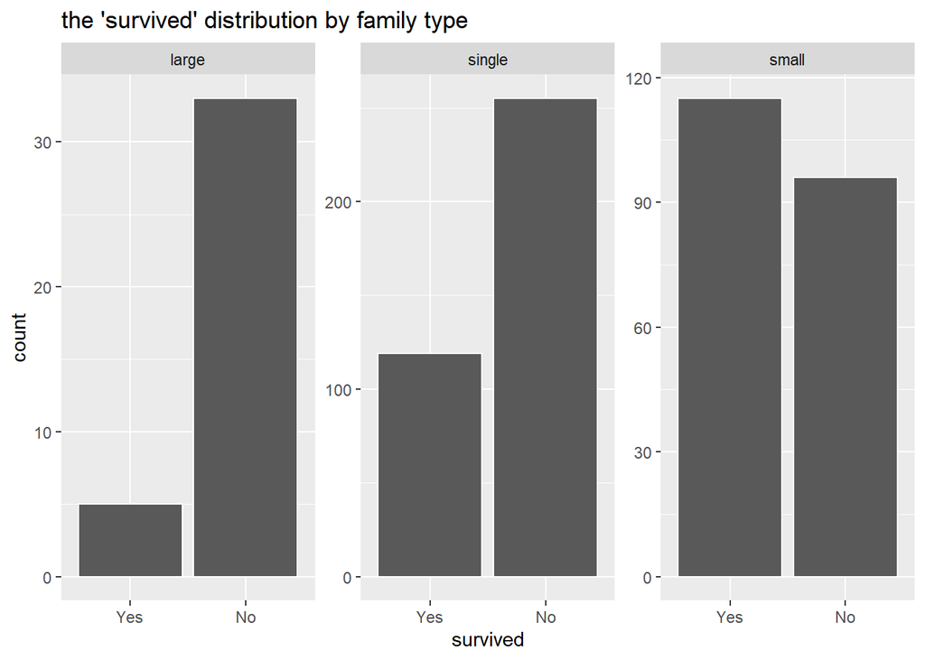

```r
# make a ggplot of the 'survived' distribution by family type.
ggplot(data_train2, aes(survived)) +
  geom_bar(color = "white") +
  facet_wrap(~ftype, scales = "free_y") +
  labs(
    title = "the 'survived' distribution by family type"
  )
```

##### Now we can truly see that the single family type and the big family type tended to be less likely to survive than the small family type.

##### Therefore, we can make sure that ‘sib_sp’, ‘parch’ are factors that we should be considering in this project.

##### 3. Let’s explore the realtionship between age, sex, and survived.

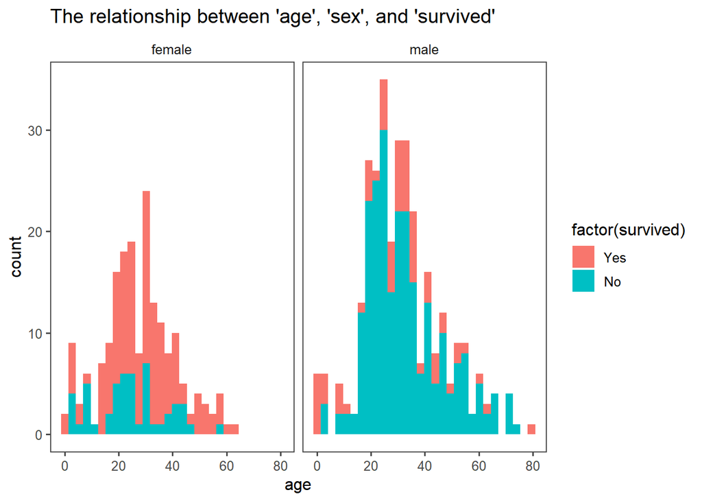

```r
ggplot(data_train[1:623,], aes(x = age, fill = factor(survived))) +
  geom_histogram(bins = 30) +
  facet_grid(.~sex) +
  theme_few() +
  labs(
    title = "The relationship between 'age', 'sex', and 'survived'"
  )
```

##### By this plot, we can see that men were less likey to survive than women. Those men between the ages of 20-30 tended to be less likely to survive than women of the same age.

##### Therefore, we can make sure that ‘age’, ‘sex’ are important factors that we should be considering in this project.

##### 4. Let’s explore the realtionship between pclass, fare, and survived.

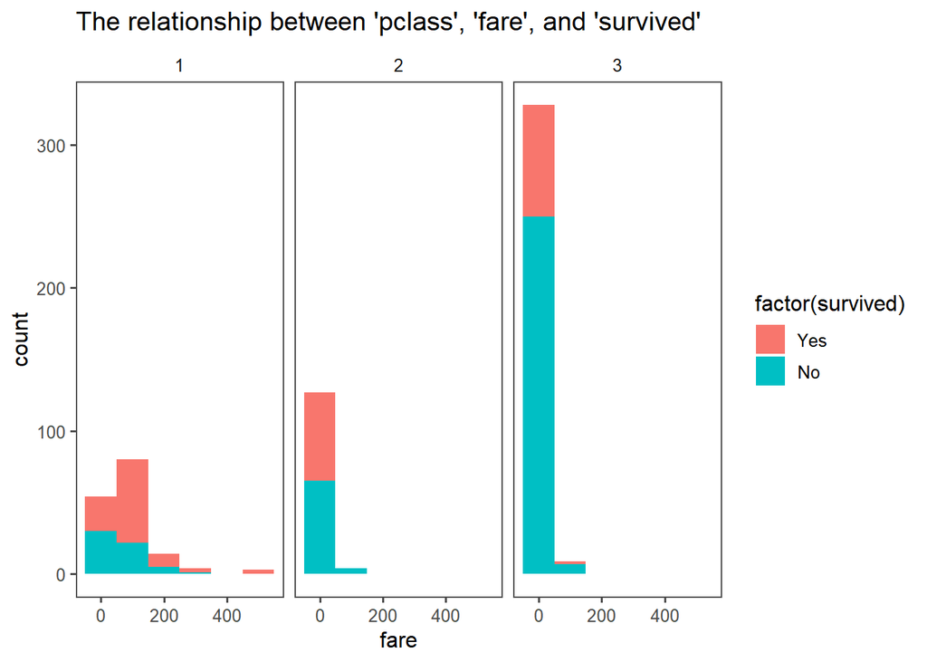

```r
ggplot(data_train[1:623,], aes(x = fare, fill = factor(survived))) +
  geom_histogram(binwidth = 100) +
  facet_grid(.~pclass) +
  theme_few() +
  labs(
    title = "The relationship between 'pclass', 'fare', and 'survived'"
  )
```

##### By this plot, we can see that pclass ‘1’ were most likey to survive, and plcass ‘3’ were least likely to survive. The mean fare of pclass ‘1’ much higher than the mean fare of pclass ‘3’.

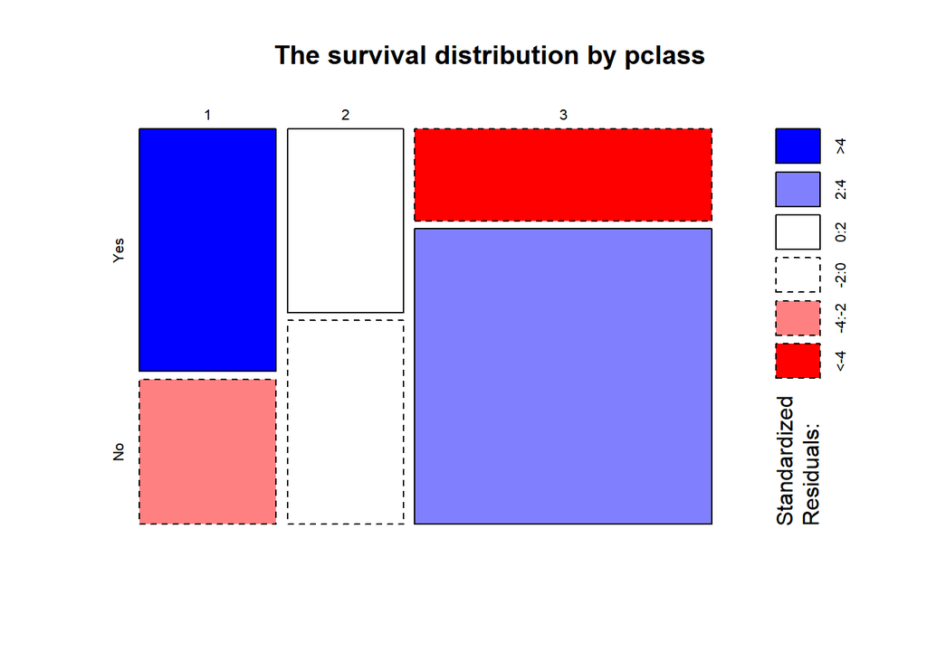

```r
mosaicplot(table(data_train$pclass, data_train$survived), main='The survival distribution by pclass', shade=TRUE)
```

##### By this mosaic plot, we can know that the pclass higher, the less tendency to survive.

##### Therefore, we can make sure that ‘pclass’, ‘fare’ are important factors that we should be considering in this project to predict which passengers would survive the Titanic shipwreck.

# Model Building

## 1. Building the Recipe

##### Let’s build the recipe.

```r
control <- control_resamples(save_pred = TRUE)

# Build the Recipe
titanic_recipe <- recipe(survived ~ pclass + sex + age + sib_sp + parch + fare, data = data_train) %>%
  step_impute_linear(age, impute_with = imp_vars(sib_sp)) %>%
  step_dummy(all_nominal_predictors()) %>%
  step_interact(~ starts_with("sex"):fare + age:fare) %>%
  step_normalize(all_predictors())

# step_impute_linear: 'age' have several missing values, so I added an imputation step, I chose 'sib_sp' to impute with 'age' because those are correlated.

# step_dummy: There are several categorical predictors, so I used 'step_dummy' function to dummy encode those categorical predictors.
```

##### In an effort to have the same information in every model R script, I saved model objects to my folder.

```r
getwd()
```

```
## [1] "C:/Users/82107/Documents/myrepo/finalproject"
```

```r
write_rds(data_train, "C:/Users/82107/Documents/myrepo/finalproject/rds/train_modelready.rds")
write_rds(data_test, "C:/Users/82107/Documents/myrepo/finalproject/rds/test_modelready.rds" )
```

```r
save(titanic_folds,titanic_recipe, data_train, file = "C:/Users/82107/Documents/myrepo/finalproject/rda/model_setup.rda" )
```

##### This included the training data folds, the recipe, and the original training data.

## 2. Running the Models for Repeated Cross Fold Validation

##### I decided to run repeated cross fold validation on the following four models, Decision Model, Random Forest Model, Boosted Tree Model, Nearest Neighbor Model, because my outcome variable is a categorical variable.

##### Before running the models, I loaded the required objects that I saved.

```r
load(file =  "C:/Users/82107/Documents/myrepo/finalproject/rda/model_setup.rda")
```

## Decision model

```r
# Set up a decision tree model.
tree_model <- decision_tree() %>%
  set_engine("rpart") %>%
  set_mode("classification")


# Set up a decision tree workflow.
tree_wf <- workflow() %>%
  add_model(tree_model %>% set_args(cost_complexity = tune())) %>%
  add_recipe(titanic_recipe)

# Create the regular grid to tune the 'cost_complexity' hyperparameter.
set.seed(1234)

tree_grid <- grid_regular(cost_complexity(range = c(-3, -1)), levels = 10)
tree_grid
```

```
## # A tibble: 10 × 1
##    cost_complexity
##              <dbl>
##  1         0.001
##  2         0.00167
##  3         0.00278
##  4         0.00464
##  5         0.00774
##  6         0.0129
##  7         0.0215
##  8         0.0359
##  9         0.0599
## 10         0.1
```

```r
# Tune the 'cost_complexity' hyperparameter.
tree_tune <- tune_grid(
  tree_wf,
  resamples = titanic_folds,
  grid = tree_grid,
  metrics = metric_set(roc_auc)
)
```

```r
# Save the results of decision model.
save(tree_tune, tree_wf, file = "C:/Users/82107/Documents/myrepo/finalproject/rda/tree_tune.rda")
```

## Random Forest Model

```r
# Set up a random forest model. I used the `ranger` engine and set `importance = "impurity" to know variable importance. I tuned `mtry`, `trees`, and `min_n` to find the best random forest model.
rf_model <- rand_forest(mtry = tune(), trees = tune(), min_n = tune()) %>%
  set_engine("ranger", importance = "impurity") %>%
  set_mode("classification")

# Set up a random forest workflow.
rf_wf <- workflow() %>%
  add_model(rf_model) %>%
  add_recipe(titanic_recipe)
```

```r
# Create the regular grid to tune the 'mtry', 'trees', 'min_n' hyperparameters. Because 'mtry' hyperparameter is the number of randomly selected predictors, 'mtry' should not be smaller than 1 or larger than 6 (We have only 6 predictors)
set.seed(1234)
rf_grid <- grid_regular(mtry(range = c(1, 6)), trees(range = c(10,100)) , min_n(range = c(10,100)), levels = 10)
rf_grid
```

```
## # A tibble: 600 × 3
##     mtry trees min_n
##    <int> <int> <int>
##  1     1    10    10
##  2     2    10    10
##  3     3    10    10
##  4     4    10    10
##  5     5    10    10
##  6     6    10    10
##  7     1    20    10
##  8     2    20    10
##  9     3    20    10
## 10     4    20    10
## # … with 590 more rows
```

```r
# Tune the hyperparameters.
rf_tune <- tune_grid(
  rf_wf,
  resamples = titanic_folds,
  grid = rf_grid,
  metrics = metric_set(roc_auc)
)
```

```r
# Save the results of random forest model.
save(rf_tune, rf_wf, file = "C:/Users/82107/Documents/myrepo/finalproject/rda/rf_tune.rda")
```

## Boosted tree model

```r
# Set up a boosted tree model. I used the `xgboost` engine and tuned `mtry`, `trees`, and `min_n` to find the best boosted tree model.
bt_model <- boost_tree(mtry = tune(), trees = tune(), min_n = tune()) %>%
  set_engine("xgboost") %>%
  set_mode("classification")

# Set up a boosted tree workflow.
bt_wf <- workflow() %>%
  add_model(bt_model) %>%
  add_recipe(titanic_recipe)
```

```r
# Create the regular grid to tune the 'mtry', 'trees', 'min_n' hyperparameters.
set.seed(1234)
bt_grid <- grid_regular(mtry(range = c(1, 6)), trees(range = c(10,100)) , min_n(range = c(10,100)), levels = 8)
```

```r
# Tune the hyperparemeters.
bt_tune <- tune_grid(
  bt_wf,
  resamples = titanic_folds,
  grid =bt_grid,
  metrics = metric_set(roc_auc))
```

```r
# Save the results of boosted tree model.
save(bt_tune, bt_wf, file = "C:/Users/82107/Documents/myrepo/finalproject/rda/bt_tune.rda")
```

## Nearest Neighbors Model

```r
# Set up a nearest neighbors model.
knn_model <-
  nearest_neighbor(
    neighbors = tune(),
    mode = "classification") %>%
  set_engine("kknn")

# Set up a nearest neighbors workflow.
knn_wf <- workflow() %>%
  add_model(knn_model) %>%
  add_recipe(titanic_recipe)
```

```r
# Create a regular grid.
set.seed(1234)
knn_params <- extract_parameter_set_dials(knn_model)
knn_grid <- grid_regular(knn_params, levels = 2)
```

```r
# Tune the hyperparameters.
knn_tune <- knn_wf %>%
  tune_grid(
    resamples = titanic_folds,
    grid = knn_grid)
```

```r
# Save the results of nearest neighbors model.
save(knn_tune, knn_wf, file = "C:/Users/82107/Documents/myrepo/finalproject/rda/knn_tune.rda")
```

# Repeated Cross Validation Model Analysis

```r
load("C:/Users/82107/Documents/myrepo/finalproject/rda/tree_tune.rda")
load("C:/Users/82107/Documents/myrepo/finalproject/rda/rf_tune.rda")
load("C:/Users/82107/Documents/myrepo/finalproject/rda/bt_tune.rda")
load("C:/Users/82107/Documents/myrepo/finalproject/rda/knn_tune.rda")
```

## Decision Tree Model

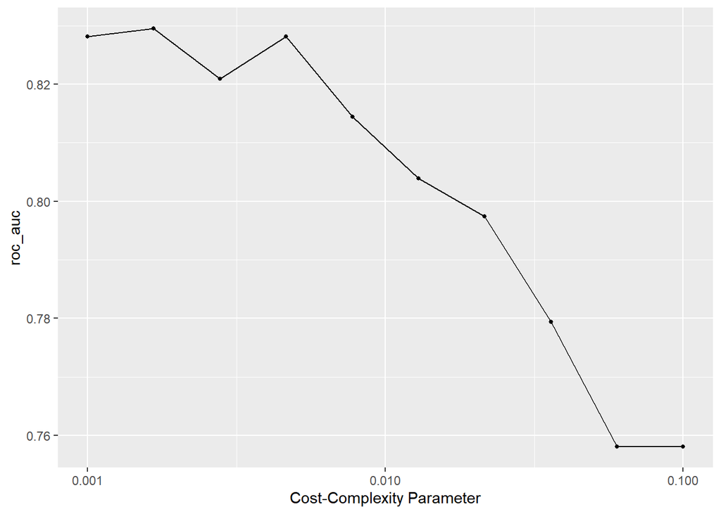

```r
autoplot(tree_tune)
```

```r
show_best(tree_tune)
```

```
## # A tibble: 5 × 7
##   cost_complexity .metric .estimator  mean     n std_err .config
##             <dbl> <chr>   <chr>      <dbl> <int>   <dbl> <chr>
## 1         0.00167 roc_auc binary     0.829    10  0.0204 Preprocessor1_Model02
## 2         0.00464 roc_auc binary     0.828    10  0.0239 Preprocessor1_Model04
## 3         0.001   roc_auc binary     0.828    10  0.0207 Preprocessor1_Model01
## 4         0.00278 roc_auc binary     0.821    10  0.0243 Preprocessor1_Model03
## 5         0.00774 roc_auc binary     0.814    10  0.0200 Preprocessor1_Model05
```

##### The ‘roc_auc’ of my best-performing pruned decision tree on the folds is ‘0.8294943’.

## Random Forest Model

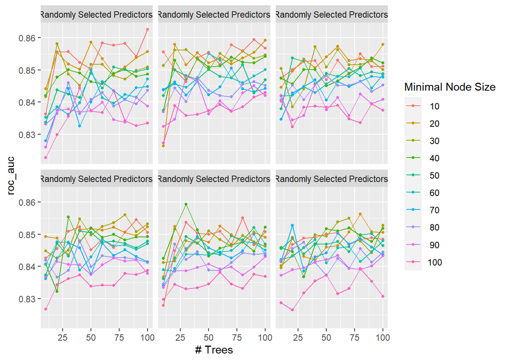

```r
autoplot(rf_tune)
```

```r
show_best(rf_tune)
```

```
## # A tibble: 5 × 9
##    mtry trees min_n .metric .estimator  mean     n std_err .config
##   <int> <int> <int> <chr>   <chr>      <dbl> <int>   <dbl> <chr>
## 1     1   100    10 roc_auc binary     0.863    10  0.0168 Preprocessor1_Model0…
## 2     2    90    10 roc_auc binary     0.859    10  0.0216 Preprocessor1_Model0…
## 3     5    30    40 roc_auc binary     0.859    10  0.0196 Preprocessor1_Model1…
## 4     2   100    20 roc_auc binary     0.859    10  0.0200 Preprocessor1_Model1…
## 5     1    50    20 roc_auc binary     0.859    10  0.0170 Preprocessor1_Model0…
```

##### The ‘roc_auc’ of my best-performing random forest on the folds is ‘0.8625725’, with mtry=1, trees = 100, min_n = 10. This is good performing model.

## Boosted Tree Model

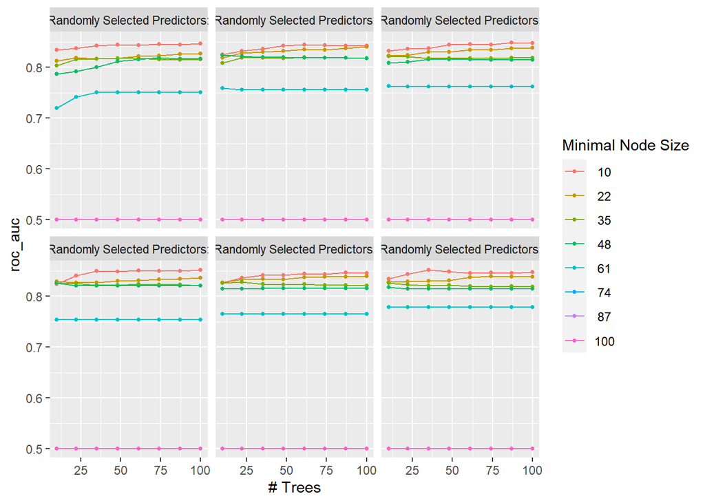

```r
autoplot(bt_tune)
```

```r
show_best(bt_tune)
```

```
## # A tibble: 5 × 9
##    mtry trees min_n .metric .estimator  mean     n std_err .config
##   <int> <int> <int> <chr>   <chr>      <dbl> <int>   <dbl> <chr>
## 1     4   100    10 roc_auc binary     0.852    10  0.0173 Preprocessor1_Model2…
## 2     6    35    10 roc_auc binary     0.851    10  0.0183 Preprocessor1_Model3…
## 3     4    61    10 roc_auc binary     0.850    10  0.0179 Preprocessor1_Model1…
## 4     4    74    10 roc_auc binary     0.850    10  0.0177 Preprocessor1_Model1…
## 5     4    35    10 roc_auc binary     0.850    10  0.0178 Preprocessor1_Model1…
```

##### The ‘roc_auc’ of my best-performing boosted tree on the folds is ‘0.8521397’, with mtry=4, trees = 100, min_n = 10. This is also quite good performing model.

## Nearest Neighbor Model

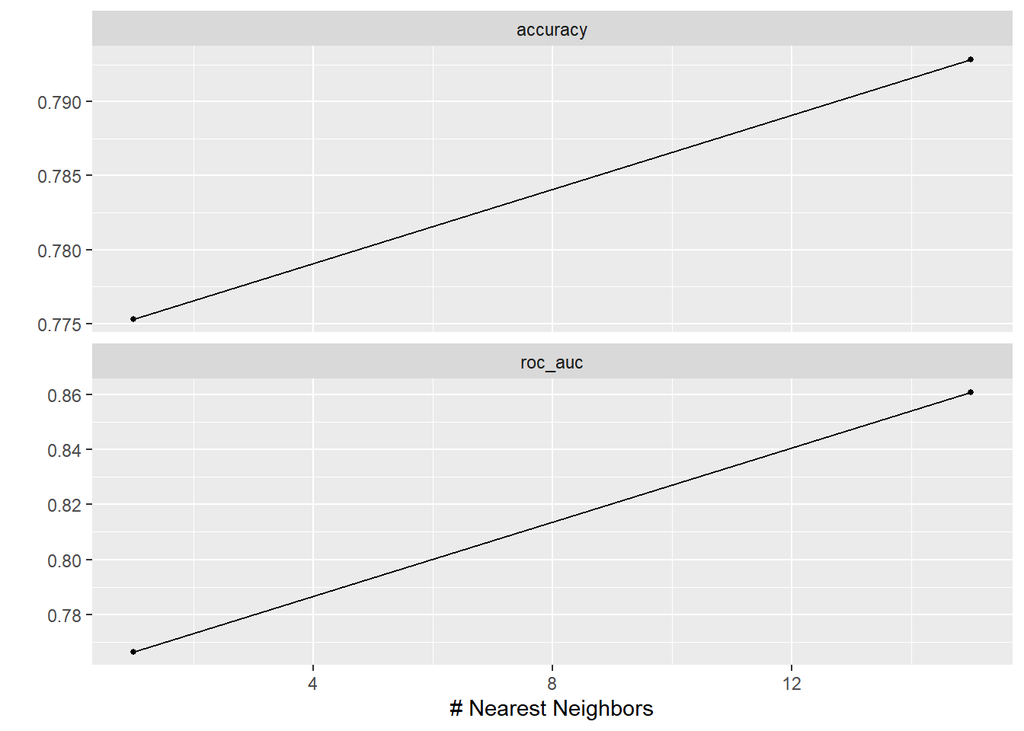

```r
autoplot(knn_tune)
```

```r
show_best(knn_tune)
```

```
## # A tibble: 2 × 7
##   neighbors .metric .estimator  mean     n std_err .config
##       <int> <chr>   <chr>      <dbl> <int>   <dbl> <chr>
## 1        15 roc_auc binary     0.861    10  0.0154 Preprocessor1_Model2
## 2         1 roc_auc binary     0.766    10  0.0236 Preprocessor1_Model1
```

##### The ‘roc_auc’ of my best-performing nearest neighbor on the folds is ‘0.8608220’, with neighbors=15. This is also quite good performing model.

### Let’s continue with the Random Forest Model being the model that performed best.

# Final Model Building

```r
# Finalize the workflow by taking the parameters from the best model(the random forest model).
rf_final <- rf_wf %>%
  finalize_workflow(select_best(rf_tune, metric = "roc_auc"))
```

```r
# Load the entire training set, which we saved as a "ready to go" data set in an earlier script.
train <- read_rds("C:/Users/82107/Documents/myrepo/finalproject/rds/train_modelready.rds")
```

```r
# Let's run the fit and write out the results.
rf_results <- fit(rf_final, train)
write_rds(rf_results, "C:/Users/82107/Documents/myrepo/finalproject/rds/titanic_modelfitting.rds" )
```

# Model Fitting and Evaluating performances

```r
# Let's load testing data set and our final model.
test <- read_rds("C:/Users/82107/Documents/myrepo/finalproject/rds/test_modelready.rds")
final_model <- read_rds("C:/Users/82107/Documents/myrepo/finalproject/rds/titanic_modelfitting.rds")
```

```r
titanic_metric <- metric_set(roc_auc)
# Let's fit the model to the testing data set.
model_test_predictions <- predict(final_model, new_data = test, type = "class") %>%
  bind_cols(test %>% select(survived)) %>%
  accuracy(truth = survived, estimate = .pred_class)

model_test_predictions
```

```
## # A tibble: 1 × 3
##   .metric  .estimator .estimate
##   <chr>    <chr>          <dbl>
## 1 accuracy binary         0.836
```

##### Using the testing data, let’s creat a confusion matrix and visualize it.

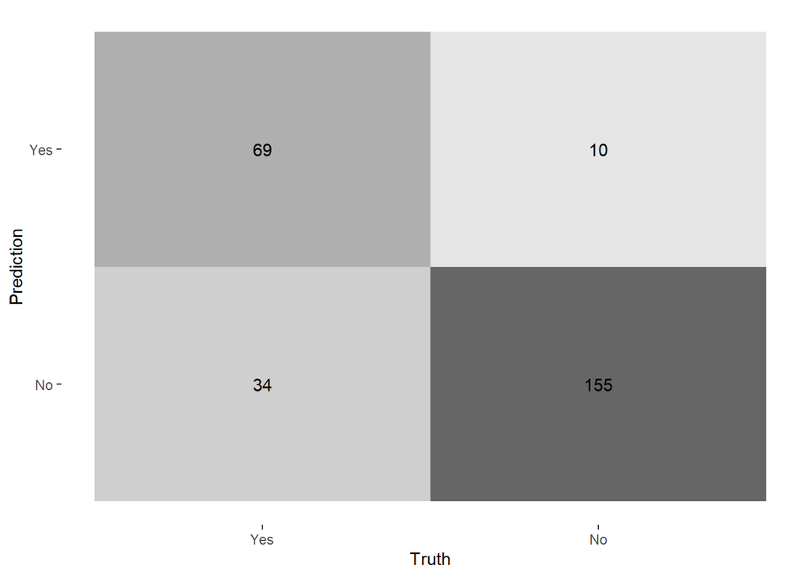

```r
augment(final_model, new_data = test) %>%
  conf_mat(truth = survived, estimate = .pred_class) %>%
  autoplot(type = "heatmap")
```

##### Let’s print the roc curve.

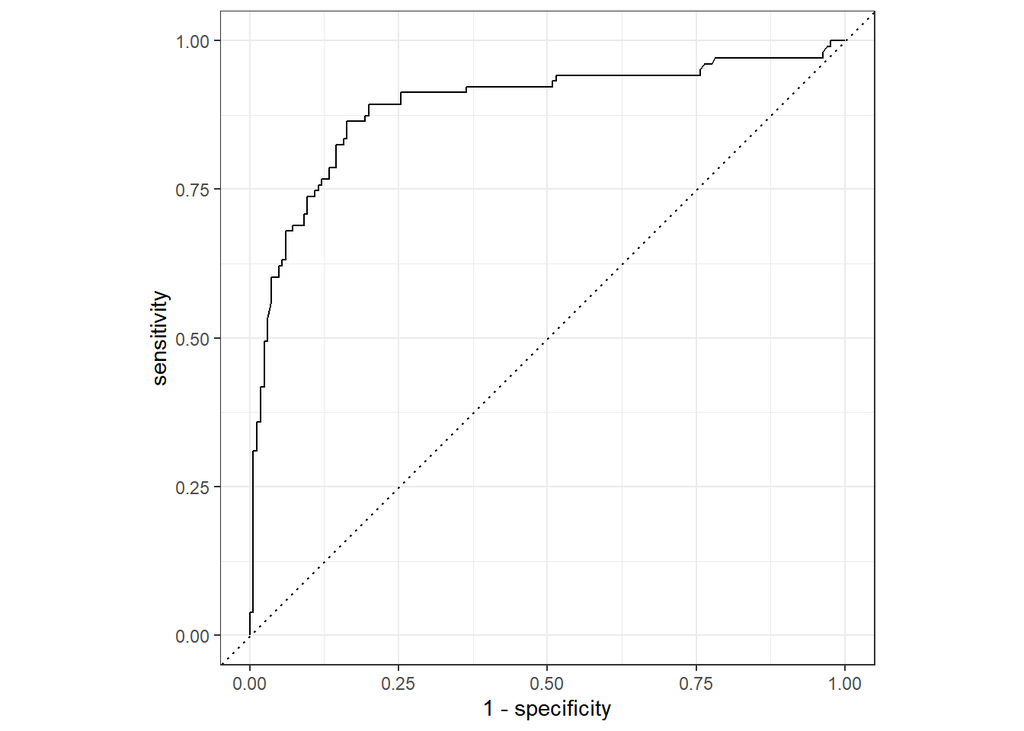

```r
augment(final_model, new_data = test) %>%
  roc_curve(survived, .pred_Yes ) %>%
  autoplot()
```

##### Based on the ROC curve, the model actually did well. Because the curve is attached to the left-up side.

# Conclusion

##### Further research avenues may be creating a neural network model that will predict which passengers would survive the Titanic shipwreck, because we only created Decision model, Random Forest model, Boosted Tree model, and Nearest Neighbor model.